# Business Statistics End of Term Assessment IB94X0 2024-2025 #2

5663499

**Declaration**

This is to certify that the work I am submitting is my own. All external references and sources are clearly acknowledged and identified within the contents. I am aware of the University of Warwick regulation concerning plagiarism and collusion.

No substantial part(s) of the work submitted here has also been submitted by me in other assessments for accredited courses of study, and I acknowledge that if this has been done an appropriate reduction in the mark, I might otherwise have received will be made.

AI was used in the preparation of this work. It was used in the development of the code: It was used to provide example uses of functions or approaches to elements of the challenges which were then interpreted by me and modified to be applicable to this data/report.

```r
# Importing the necessary R libraries
library(tidyverse)
library(gridExtra)
library(grid)
library(emmeans) # for emmeans() and pairs()
library(lubridate)
library(Hmisc) # for correlation functions
library(car) # for vif()
library(dplyr)
```

# Question 1

## Importing the data

```r
# Importing the CSV file
cardio.disease <- read_csv("Cardio_Vascular_Disease.txt")
# Get the imported table's specifications
spec(cardio.disease)
```

**Data Table**

This data is from various datasets from the UK Office for National Statistics where each row of the data represents one local authority region. The table shows the part of population that is suffering from factors like overweight, smokers, wellbeing and poverty. The variables are described in the table below:

| Variable | Description |
| --- | --- |
| area_name | Name of the city where the data was collected |
| area_code | Pincode of the area where the data was collected |
| Population | Amount of people living in that area |
| Poverty | Percentage of people living in poverty in that area |
| CVD | Percentage of people who suffers from Cardiovascular Disease (CVD) in that area |
| overweight | Percentage of people who are overweight in that area |
| smokers | Percentage of people who are smokers in that area |
| wellbeing | Average wellbeing score of people living in that area |

## Performing Exploratory Data Analysis (EDA)

```r
# Print the first 5 rows of the imported data table
head(cardio.disease)
```

```
## # A tibble: 6 × 8
##   area_name      area_code Population Poverty   CVD overweight smokers wellbeing
##   <chr>          <chr>          <dbl>   <dbl> <dbl>      <dbl>   <dbl>     <dbl>
## 1 Hartlepool     E06000001      88905    23    13.7       34.6    17.3      7.33
## 2 Middlesbrough  E06000002     133375    25.1  13.1       32.0    17.9      7.21
## 3 Redcar and Cl… E06000003     131035    21.4  15         33.4    13.3      7.44
## 4 Stockton-on-T… E06000004     186365    19.5  12.4       40.2    12.5      7.4
## 5 Darlington     E06000005     104300    19.7  11.9       35.7    10.6      7.25
## 6 Halton         E06000006     125725    21.9  15.7       32.3    13.2      7.29
```

```r
# Summarise the imported table data and get the details about each column to better understand the data
summary(cardio.disease)
```

```
##   area_name          area_code           Population         Poverty
##  Length:385         Length:385         Min.   :   1960   Min.   :12.90
##  Class :character   Class :character   1st Qu.: 100640   1st Qu.:16.90
##  Mode  :character   Mode  :character   Median : 135275   Median :18.70
##                                        Mean   : 174804   Mean   :19.34
##                                        3rd Qu.: 216600   3rd Qu.:21.40
##                                        Max.   :1056970   Max.   :30.70
##                                        NA's   :76        NA's   :76
##       CVD          overweight       smokers        wellbeing
##  Min.   : 7.90   Min.   :10.24   Min.   : 3.20   Min.   :6.610
##  1st Qu.:10.90   1st Qu.:21.63   1st Qu.:10.72   1st Qu.:7.280
##  Median :12.30   Median :25.52   Median :12.80   Median :7.410
##  Mean   :12.42   Mean   :25.52   Mean   :13.07   Mean   :7.423
##  3rd Qu.:14.10   3rd Qu.:29.46   3rd Qu.:15.30   3rd Qu.:7.560
##  Max.   :17.80   Max.   :40.22   Max.   :27.80   Max.   :8.170
##  NA's   :76      NA's   :72      NA's   :7       NA's   :15
```

```r
# Check for the NA values present in our dataset
summarise_all( cardio.disease , ~ sum (is.na(.x)))
```

```
## # A tibble: 1 × 8
##   area_name area_code Population Poverty   CVD overweight smokers wellbeing
##       <int>     <int>      <int>   <int> <int>      <int>   <int>     <int>
## 1         0         0         76      76    76         72       7        15
```

From the above summary we can see the `NA` values present in the data. There are 76 `NA` values in the *Population*, *Poverty* and *CVD* Columns. 72 `NA` values in *overweight* column, 7 `NA` values in *smokers* column and 15 `NA` values in *wellbeing* column.

```r
# To check the number of unique values present in the area_name column
distinct_areas <- length(unique(cardio.disease$area_name))
print(distinct_areas)
```

```
## [1] 385
```

There are 385 different distinct areas present in the data table.

```r
# To check if there are any repeated values present in the area_code column
repeated_code <- cardio.disease$area_code[duplicated(cardio.disease$area_code)]
print(repeated_code)
```

```
## character(0)
```

There are no repeated values in the *area_code* column.

```r
# To check if there are any repeated values present in the area_name column
repeated_area <- cardio.disease$area_name[duplicated(cardio.disease$area_name)]
print(repeated_area)
```

```
## character(0)
```

There are no repeated values in the *area_name* column.

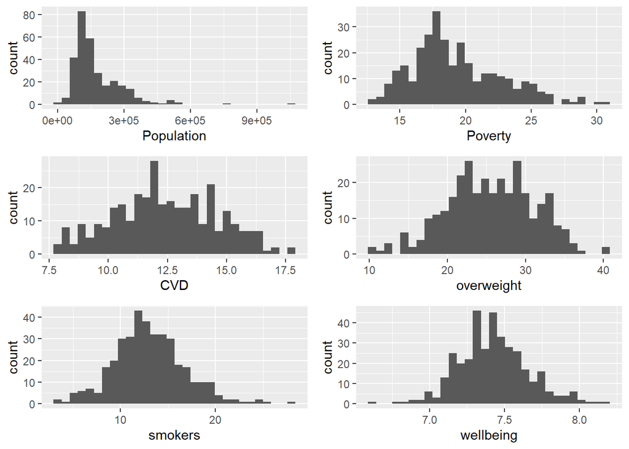

```r
# Plotting the histogram graph for all the different columns and arranging them in a grid
grid.arrange(
ggplot(cardio.disease) + geom_histogram(aes(Population), bins = 30),
ggplot(cardio.disease) + geom_histogram(aes(Poverty), bins = 30),
ggplot(cardio.disease) + geom_histogram(aes(CVD), bins = 30),
ggplot(cardio.disease) + geom_histogram(aes(overweight), bins = 30),
ggplot(cardio.disease) + geom_histogram(aes(smokers), bins = 30),
ggplot(cardio.disease) + geom_histogram(aes(wellbeing), bins = 30)
)
```

To check for the outlier present in the data, we can use Histogram to check for these outlier. After plotting the data using histogram, we notice that *Population* column contain some outlier but as these values represent the number of people living in that specific area, so it is logical for them to be present. The remaining columns doesn’t contain any noticeable outlier and the few noticeable ones that are present are logical.

## Performing Data Manipulation

```r
# Dealing with the NA values present in the dataset by removing them
cardio.disease <- na.omit(cardio.disease)
summarise_all( cardio.disease , ~ sum (is.na(.x)))
```

```
## # A tibble: 1 × 8
##   area_name area_code Population Poverty   CVD overweight smokers wellbeing
##       <int>     <int>      <int>   <int> <int>      <int>   <int>     <int>
## 1         0         0          0       0     0          0       0         0
```

To deal with the `NA` values, as the columns where missing values are present, span over multiple columns in the same row, it would be better to remove the rows which contain the `NA` value as filling them with any different type of values (mean, median, mode, average, minimum or maximum) would effect the calculations as the data is from real world scenario.

## Performing statistical modelling and analysis

```r
# Make the correlation matrix between all the columns
rcorr(as.matrix(select_if(cardio.disease, is.numeric)))
```

```
##            Population Poverty   CVD overweight smokers wellbeing
## Population       1.00    0.33 -0.20      -0.02    0.06     -0.21
## Poverty          0.33    1.00 -0.25       0.14    0.36     -0.35
## CVD             -0.20   -0.25  1.00       0.32    0.18      0.25
## overweight      -0.02    0.14  0.32       1.00    0.40     -0.04
## smokers          0.06    0.36  0.18       0.40    1.00     -0.20
## wellbeing       -0.21   -0.35  0.25      -0.04   -0.20      1.00
##
## n= 303
##
##
## P
##            Population Poverty CVD    overweight smokers wellbeing
## Population            0.0000  0.0004 0.6844     0.3239  0.0003
## Poverty    0.0000             0.0000 0.0152     0.0000  0.0000
## CVD        0.0004     0.0000         0.0000     0.0019  0.0000
## overweight 0.6844     0.0152  0.0000            0.0000  0.4681
## smokers    0.3239     0.0000  0.0019 0.0000             0.0005
## wellbeing  0.0003     0.0000  0.0000 0.4681     0.0005
```

The correlation analysis is conducted using correlation matrix to examine the relationships among variables related to *cardiovascular disease* (CVD): *Population*, *Poverty*, *CVD* prevalence, *Overweight*, *Smokers*, and *Wellbeing*. The correlation coefficients ($𝑟$) and corresponding p-values are summarized above.

```r
# Performing multiple regression by developing a base model (model 1)
m.cvd.1 <- lm(CVD ~ Poverty + wellbeing + smokers + overweight, data= cardio.disease)
summary(m.cvd.1)
```

```
##
## Call:
## lm(formula = CVD ~ Poverty + wellbeing + smokers + overweight,
##     data = cardio.disease)
##
## Residuals:
##     Min      1Q  Median      3Q     Max
## -4.3966 -1.4313 -0.1097  1.3905  4.7779
##
## Coefficients:
##             Estimate Std. Error t value Pr(>|t|)
## (Intercept) -1.69780    3.93361  -0.432 0.666335
## Poverty     -0.18400    0.03515  -5.234 3.13e-07 ***
## wellbeing    1.80025    0.49096   3.667 0.000291 ***
## smokers      0.12030    0.03366   3.574 0.000410 ***
## overweight   0.10985    0.02123   5.174 4.22e-07 ***
## ---
## Signif. codes:  0 '***' 0.001 '**' 0.01 '*' 0.05 '.' 0.1 ' ' 1
##
## Residual standard error: 1.894 on 298 degrees of freedom
## Multiple R-squared:  0.2494, Adjusted R-squared:  0.2393
## F-statistic: 24.75 on 4 and 298 DF,  p-value: < 2.2e-16
```

```r
# Finding the confidence intervals of the estimate mean values of the model 1
confint(m.cvd.1)
```

```
##                   2.5 %     97.5 %
## (Intercept) -9.43896508  6.0433707
## Poverty     -0.25317844 -0.1148195
## wellbeing    0.83405073  2.7664450
## smokers      0.05405715  0.1865512
## overweight   0.06806757  0.1516385
```

Multiple Regression shows that with every one 1 percent increase in *wellbeing* ($b = 1.80$, CI = [0.834, 2.766], $t(298)=3.667$, $p=0.0002$) *CVD* rate increases by 1.8 percent, for every 1 percent increase in *smokers* ($b = 0.120$, CI = [0.054, 0.186], $t(298)=3.574$, $p=0.0004$) *CVD* rate increase by 0.12 percent and for every 1 percent increase in *overweight* ($b = 0.109$, CI = [0.068, 0.151], $t(298)=5.174$, $p<0.05$) *CVD* rate increases by 0.109 percent which shows a significant positive impact upon *CVD* which means as *wellbeing*, *smokers* and *overweight* rate increases, *CVD* also increase. Whereas with every 1 percent increase in *Poverty* ($b = -0.184$, CI = [-0.253, -0.114], $t(298)=-5.234$, $p<0.05$) *CVD* rate decreases by 0.18 percent which means it has a Negative impact on *CVD* which means as *Poverty* increases, the rate of *cardiovascular disease* decreases.

```r
# Varience Inflation Factor score calculations for all the variables
vif(m.cvd.1)
```

```
##    Poverty  wellbeing    smokers overweight
##   1.263094   1.145506   1.359206   1.196546
```

We can use Variance Inflation Factor scores (VIFs) to get a measure of collinearity within our regression models. Generally, VIF scores of less than 5 don’t warrant any further action. When they are greater than 5 we have to consider whether it is justified keeping all of the predictors in the model. But as the VIF scores of our model’s variables is very less, we do not need to worry about the collinearity within our model.

```r
# Performing multiple regression by introducing interaction term in the model 2
m.cvd.2 <- lm(CVD ~ Poverty*overweight + smokers + wellbeing, data= cardio.disease)
summary(m.cvd.2)
```

```
##
## Call:
## lm(formula = CVD ~ Poverty * overweight + smokers + wellbeing,
##     data = cardio.disease)
##
## Residuals:
##     Min      1Q  Median      3Q     Max
## -4.2566 -1.3920 -0.2149  1.3413  4.6777
##
## Coefficients:
##                     Estimate Std. Error t value Pr(>|t|)
## (Intercept)         6.044246   4.869750   1.241 0.215518
## Poverty            -0.533549   0.136509  -3.909 0.000115 ***
## overweight         -0.185687   0.113565  -1.635 0.103093
## smokers             0.110702   0.033525   3.302 0.001077 **
## wellbeing           1.721960   0.486983   3.536 0.000471 ***
## Poverty:overweight  0.014638   0.005528   2.648 0.008526 **
## ---
## Signif. codes:  0 '***' 0.001 '**' 0.01 '*' 0.05 '.' 0.1 ' ' 1
##
## Residual standard error: 1.875 on 297 degrees of freedom
## Multiple R-squared:  0.2667, Adjusted R-squared:  0.2543
## F-statistic:  21.6 on 5 and 297 DF,  p-value: < 2.2e-16
```

```r
# Finding the confidence intervals of the estimate mean values of the model 2
confint(m.cvd.2)
```

```
##                           2.5 %      97.5 %
## (Intercept)        -3.539340992 15.62783357
## Poverty            -0.802195783 -0.26490166
## overweight         -0.409180732  0.03780701
## smokers             0.044725732  0.17667884
## wellbeing           0.763584529  2.68033554
## Poverty:overweight  0.003759743  0.02551642
```

Multiple Regression using interaction term between *Povery and Overweight* shows that with every one 1 percent increase in *wellbeing* ($b = 1.71$, CI = [0.763, 2.680], $t(297)=3.536$, $p=0.0004$) *CVD* rate increases by 1.7 percent, for every 1 percent increase in *smokers* ($b = 0.110$, CI = [0.044, 0.176], $t(297)=3.302$, $p=0.001$) *CVD* rate increase by 0.11 percent and for every 1 percent increase in *poverty and overweight* interaction ($b = 0.014$, CI = [0.003, 0.025], $t(297)=2.648$, $p=0.008$) *CVD* rate increases by 0.014 percent which shows a significant positive impact upon *CVD*. Whereas with every 1 percent increase in *Poverty* ($b = -0.533$, CI = [-0.802, -0.264], $t(297)=-3.909$, $p=0.0001$) *CVD* rate decreases by 0.53 percent and with every 1 percent increase in *overweight* ($b = -0.185$, CI = [-0.409, 0.037], $t(297)=-1.635$, $p=0.103$) *CVD* rate decreases by 0.18 percent which is not statistically significant. This shows that these two have a Negative impact on *CVD*.

```r
# Performing the analysis of variance on the two models to check for any performance increase between the two models
anova(m.cvd.1, m.cvd.2)
```

```
## Analysis of Variance Table
##
## Model 1: CVD ~ Poverty + wellbeing + smokers + overweight
## Model 2: CVD ~ Poverty * overweight + smokers + wellbeing
##   Res.Df    RSS Df Sum of Sq      F   Pr(>F)
## 1    298 1068.6
## 2    297 1043.9  1    24.649 7.0127 0.008526 **
## ---
## Signif. codes:  0 '***' 0.001 '**' 0.01 '*' 0.05 '.' 0.1 ' ' 1
```

The ANOVA results compare the base model (model 1) and the interaction model (model 2) to assess whether including the interaction term (Poverty * Overweight) significantly improves the model’s performance. The addition of the interaction term reduces the Residual Sum of Squares (RSS) from 1068.6 in the model 1 to 1043.9 in the model 2, indicating a better fit. This improvement is supported by an F-statistic of 7.013 (p = 0.0085), demonstrating that the interaction term makes a minor significant difference to the model. The interaction model also explains slightly more variance in *CVD* rates, with an R² of 0.2667 compared to 0.2494 in the base model. This indicates that the interaction between *Poverty and Overweight* contributes some valuable insights for understanding *CVD* rates.

## Visualisation

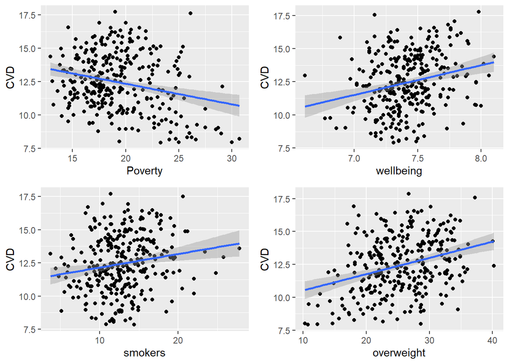

```r
# Plotting the interaction of CVD with other variables as a scatter plot
grid.arrange(
ggplot(cardio.disease, aes(y=CVD, x=Poverty)) + geom_jitter(width=.0, height=0.1) + geom_smooth(method ="lm"),
ggplot(cardio.disease, aes(y=CVD, x=wellbeing)) + geom_jitter(width=0, height=0.1) + geom_smooth(method ="lm"),
ggplot(cardio.disease, aes(y=CVD, x=smokers)) + geom_jitter(width=0, height=0.1) + geom_smooth(method ="lm"),
ggplot(cardio.disease, aes(y=CVD, x=overweight)) + geom_jitter(width=0, height=0.1) + geom_smooth(method ="lm"),
ncol=2)
```

The scatter plot above supports our analysis and shows a positive relationship between *wellbeing*, *smokers*, *overweight* and *CVD* whereas a negative relation can be seen between *Poverty* and *CVD*.

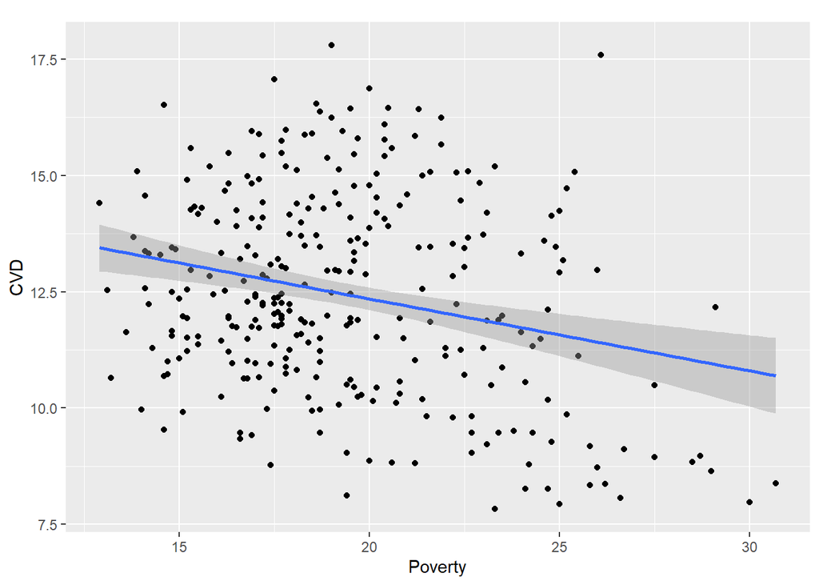

```r
ggplot(cardio.disease, aes(y=CVD, x=Poverty)) + geom_jitter(width=0, height=0.1) + labs(x="Poverty", y="CVD", title=expression()) + geom_smooth(method='lm')
```

The above scatter plot and regression line signifies the negative relation between *CVD* and *Poverty*. This means that as the *Poverty* percentage increases, the *CVD* percentage decreases.

# Question 2

## Importing the data

```r
# Importing the CSV file
cust.satisfaction <- read_csv("cust_satisfaction.txt")
# Get the imported table's specifications
spec(cust.satisfaction)
```

**Data Table**

This data is provided by a furniture retail company. The variables are described in the table below:

| Variable | Description |
| --- | --- |
| SES_category | Company’s categorisation of store type by local Socio Economic-Status |
| customer.satisfaction | Average customer satisfaction score |
| staff.satisfaction | Average staff job satisfaction score |
| delivery.time | Average delivery time of large and custom items |
| new_range | Whether the store was carrying a new range of products or not |

```r
# Renaming the column names for better interpretation
cust.satisfaction <- cust.satisfaction %>%
  rename(
    SESCategory = SES_category,
    CustSatisfaction = customer.satisfaction,
    StaffSatisfaction = staff.satisfaction,
    DeliveryTime = delivery.time,
    NewRange = new_range
  )
```

## Performing Exploratory Data Analysis (EDA)

```r
# Print the first 5 rows of the imported data table
head(cust.satisfaction)
```

```
## # A tibble: 6 × 5
##   SESCategory CustSatisfaction StaffSatisfaction DeliveryTime NewRange
##   <chr>                  <dbl>             <dbl>        <dbl> <lgl>
## 1 Medium                  7.27              6.88         66.7 FALSE
## 2 Medium                  7.93              7.44         68.2 FALSE
## 3 Medium                  7.12              7.15         70.7 FALSE
## 4 High                    6.35              6.47         61.4 TRUE
## 5 High                    6.78              7.06         57.7 TRUE
## 6 Medium                  8.07              7.03         38.0 TRUE
```

```r
# Summarise the imported table data and getting the details about each column to better understand the data
summary(cust.satisfaction)
```

```
##  SESCategory        CustSatisfaction StaffSatisfaction  DeliveryTime
##  Length:300         Min.   :3.760    Min.   :4.850     Min.   :32.96
##  Class :character   1st Qu.:6.099    1st Qu.:6.216     1st Qu.:52.46
##  Mode  :character   Median :7.006    Median :6.634     Median :60.45
##                     Mean   :6.930    Mean   :6.751     Mean   :59.60
##                     3rd Qu.:7.865    3rd Qu.:7.274     3rd Qu.:66.79
##                     Max.   :9.670    Max.   :8.860     Max.   :92.48
##   NewRange
##  Mode :logical
##  FALSE:142
##  TRUE :158
##
##
##
```

```r
# Check for the NA values present in our dataset
summarise_all( cust.satisfaction , ~ sum (is.na(.x)))
```

```
## # A tibble: 1 × 5
##   SESCategory CustSatisfaction StaffSatisfaction DeliveryTime NewRange
##         <int>            <int>             <int>        <int>    <int>
## 1           0                0                 0            0        0
```

From the above table we can see that there are no `NA` values in our dataset.

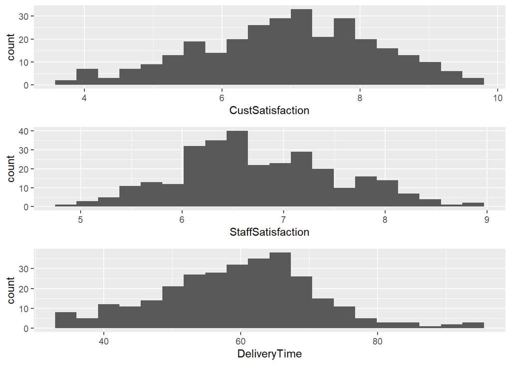

```r
# Plotting the histogram graph for the different columns
grid.arrange(
ggplot(cust.satisfaction) + geom_histogram(aes(CustSatisfaction), bins = 20),
ggplot(cust.satisfaction) + geom_histogram(aes(StaffSatisfaction), bins = 20),
ggplot(cust.satisfaction) + geom_histogram(aes(DeliveryTime), bins = 20)
)
```

The histogram shows the absence of any outliers present in our data.

## Performing statistical modelling and analysis

```r
# Convert the SESCategory HIGH, MEDIUM and LOW into Factors
cust.satisfaction$SESCategory <- factor(cust.satisfaction$SESCategory, levels = c("Low", "Medium", "High"))
# Summarise the amount of data present in each category of SESCategory column
cust.satisfaction %>% group_by(SESCategory) %>% summarise(n())
```

```
## # A tibble: 3 × 2
##   SESCategory `n()`
##   <fct>       <int>
## 1 Low           100
## 2 Medium        100
## 3 High          100
```

As now we have prepared our data for the modelling, we can move on the modelling part.

```r
# Performing multiple regression by developing a base model (without the interaction term)
m.cust.satisfaction <- lm(CustSatisfaction ~ SESCategory + DeliveryTime + StaffSatisfaction + NewRange, data = cust.satisfaction)
summary(m.cust.satisfaction)
```

```
##
## Call:
## lm(formula = CustSatisfaction ~ SESCategory + DeliveryTime +
##     StaffSatisfaction + NewRange, data = cust.satisfaction)
##
## Residuals:
##      Min       1Q   Median       3Q      Max
## -2.59866 -0.67952 -0.01176  0.65469  2.89231
##
## Coefficients:
##                    Estimate Std. Error t value Pr(>|t|)
## (Intercept)        4.962568   0.605210   8.200 7.55e-15 ***
## SESCategoryMedium  1.465058   0.155593   9.416  < 2e-16 ***
## SESCategoryHigh    0.255765   0.138541   1.846 0.065878 .
## DeliveryTime      -0.017220   0.004948  -3.480 0.000577 ***
## StaffSatisfaction  0.351113   0.080457   4.364 1.77e-05 ***
## NewRangeTRUE       0.093878   0.112249   0.836 0.403643
## ---
## Signif. codes:  0 '***' 0.001 '**' 0.01 '*' 0.05 '.' 0.1 ' ' 1
##
## Residual standard error: 0.9687 on 294 degrees of freedom
## Multiple R-squared:  0.447,  Adjusted R-squared:  0.4376
## F-statistic: 47.53 on 5 and 294 DF,  p-value: < 2.2e-16
```

```r
# Finding the confidence intervals of the estimate mean values of the model
confint(m.cust.satisfaction)
```

```
##                         2.5 %       97.5 %
## (Intercept)        3.77147459  6.153661005
## SESCategoryMedium  1.15884194  1.771274609
## SESCategoryHigh   -0.01689271  0.528422930
## DeliveryTime      -0.02695804 -0.007481643
## StaffSatisfaction  0.19276839  0.509457959
## NewRangeTRUE      -0.12703512  0.314791616
```

The *baseline customer satisfaction* score ($b = 4.962$, CI = [3.771, 6.153], $t(294)=8.200$, $p<0.05$) when all predictors are at their reference levels (e.g., *SES* is low, *DeliveryTime* = 0, *NewRange* is `FALSE` etc.) is approximately 4.96. Stores in *medium SES* areas ($b = 1.465$, CI = [1.158, 1.771], $t(294)=9.416$, $p<0.05$) have a *customer satisfaction* score that is, on average, 1.47 points higher than stores in *low SES* areas, holding all else constant. Stores in *high SES* areas ($b = 0.255$, CI = [-0.016, 0.528], $t(294)=1.846$, $p=0.06$) have a *customer satisfaction* score 0.26 points higher than *low SES* stores. This effect is marginally significant. Each additional unit increase in *delivery time* ($b = -0.017$, CI = [-0.026, -0.007], $t(294)=-3.480$, $p=0.0005$) is associated with a decrease in *customer satisfaction* by 0.017 points, holding other variables constant. This effect is also statistically significant. Whereas a one-unit increase in *staff satisfaction* ($b = 0.351$, CI = [0.192, 0.509], $t(294)=4.364$, $p<0.05$) is associated with a 0.35-point increase in *customer satisfaction*. This effect is significant. Stores carrying the *new product range* ($b = 0.093$, CI = [-0.127, 0.314], $t(294)=0.836$, $p=0.403$) have a customer satisfaction score 0.094 points higher than those that do not, but this effect is not statistically significant.

```r
# Varience Inflation Factor score calculations for all the variables
vif(m.cust.satisfaction, type='predictor')
```

```
## GVIFs computed for predictors
```

```
##                       GVIF Df GVIF^(1/(2*Df)) Interacts With
## SESCategory       1.319039  2        1.071678           --
## DeliveryTime      1.041958  1        1.020763           --
## StaffSatisfaction 1.274924  1        1.129125           --
## NewRange          1.004263  1        1.002129           --
##                                               Other Predictors
## SESCategory          DeliveryTime, StaffSatisfaction, NewRange
## DeliveryTime          SESCategory, StaffSatisfaction, NewRange
## StaffSatisfaction          SESCategory, DeliveryTime, NewRange
## NewRange          SESCategory, DeliveryTime, StaffSatisfaction
```

We can use Variance Inflation Factor scores (VIFs) to get a measure of collinearity within our regression model predictors. All the predictors show low GVIF values, indicating that multicollinearity is not a significant concern in this model. This means that the predictors are sufficiently independent of each other, and the regression model is likely to provide stable and reliable coefficient estimates.

```r
# Performing multiple regression by developing a base model (with the interaction term)
m.cust.satisfaction.2 <- lm(CustSatisfaction ~ DeliveryTime * SESCategory + StaffSatisfaction + NewRange, data = cust.satisfaction)
summary(m.cust.satisfaction.2)
```

```
##
## Call:
## lm(formula = CustSatisfaction ~ DeliveryTime * SESCategory +
##     StaffSatisfaction + NewRange, data = cust.satisfaction)
##
## Residuals:
##      Min       1Q   Median       3Q      Max
## -2.69336 -0.63905 -0.02235  0.64181  2.70571
##
## Coefficients:
##                                 Estimate Std. Error t value Pr(>|t|)
## (Intercept)                     4.068239   0.730090   5.572 5.72e-08 ***
## DeliveryTime                   -0.003839   0.007972  -0.482  0.63049
## SESCategoryMedium               2.224086   0.705663   3.152  0.00179 **
## SESCategoryHigh                 2.225232   0.750829   2.964  0.00329 **
## StaffSatisfaction               0.359605   0.079847   4.504 9.67e-06 ***
## NewRangeTRUE                    0.104057   0.111400   0.934  0.35103
## DeliveryTime:SESCategoryMedium -0.012181   0.011622  -1.048  0.29548
## DeliveryTime:SESCategoryHigh   -0.032463   0.012156  -2.670  0.00800 **
## ---
## Signif. codes:  0 '***' 0.001 '**' 0.01 '*' 0.05 '.' 0.1 ' ' 1
##
## Residual standard error: 0.9603 on 292 degrees of freedom
## Multiple R-squared:  0.4602, Adjusted R-squared:  0.4473
## F-statistic: 35.57 on 7 and 292 DF,  p-value: < 2.2e-16
```

```r
# Finding the confidence intervals of the estimate mean values of the model
confint(m.cust.satisfaction.2)
```

```
##                                      2.5 %       97.5 %
## (Intercept)                     2.63133395  5.505144708
## DeliveryTime                   -0.01952751  0.011850333
## SESCategoryMedium               0.83525551  3.612916937
## SESCategoryHigh                 0.74750992  3.702954204
## StaffSatisfaction               0.20245732  0.516753329
## NewRangeTRUE                   -0.11519251  0.323306442
## DeliveryTime:SESCategoryMedium -0.03505429  0.010692947
## DeliveryTime:SESCategoryHigh   -0.05638729 -0.008537739
```

The model shows a slight improvement over the base model, with an $R^2$ of 0.460 and an Adjusted $R^2$ of 0.447, meaning it explains a bit more of the variation in *customer satisfaction*. The residual standard error drops to 0.960, indicating better prediction accuracy. *Medium SES* stores report *customer satisfaction* scores that are 2.22 points higher than *low SES* stores ($p = 0.00179$), and *high SES* stores score 2.23 points higher ($p = 0.00329$). *Staff satisfaction* has a notable positive effect, with a 0.36 point increase in satisfaction for every one-unit increase in *staff satisfaction* ($p < 0.001$). *Delivery time*, by itself, doesn’t significantly affect *customer satisfaction* ($p = 0.63049$), but in *high SES* stores, longer *delivery times* lead to a significant drop in satisfaction ($Estimate = -0.0325$ , $p = 0.00800$). The interaction term highlights how the effect of *delivery time* varies across *SES* groups, showing no significant impact for *medium SES* stores ($p = 0.29548$). Carrying a new product range does not significantly impact satisfaction ($p = 0.35103$). These findings suggest that improving delivery strategies in *high SES* areas and focusing on boosting *staff satisfaction* in all stores would be effective ways to increase *customer satisfaction*.

```r
# Performing the analysis of variance on the two models to check for any performance increase between the two models
anova(m.cust.satisfaction, m.cust.satisfaction.2)
```

```
## Analysis of Variance Table
##
## Model 1: CustSatisfaction ~ SESCategory + DeliveryTime + StaffSatisfaction +
##     NewRange
## Model 2: CustSatisfaction ~ DeliveryTime * SESCategory + StaffSatisfaction +
##     NewRange
##   Res.Df    RSS Df Sum of Sq      F  Pr(>F)
## 1    294 275.86
## 2    292 269.26  2    6.6032 3.5805 0.02909 *
## ---
## Signif. codes:  0 '***' 0.001 '**' 0.01 '*' 0.05 '.' 0.1 ' ' 1
```

```r
# Create a sequence of 5 evenly spaced delivery time values ranging from the minimum to the maximum delivery time in the dataset.
# This will be used for predictions or plotting to analyze the relationship between DeliveryTime and other variables.
delivery_time_range <- seq(min(cust.satisfaction$DeliveryTime),
                           max(cust.satisfaction$DeliveryTime),
                           length.out = 5)
```

```r
# Calculate the estimated marginal means (EMMs) for DeliveryTime across different SESCategory levels
emm <- emmeans(m.cust.satisfaction.2, ~DeliveryTime | SESCategory, at = list(DeliveryTime = delivery_time_range))
print(emm)
```

```
## SESCategory = Low:
##  DeliveryTime emmean    SE  df lower.CL upper.CL
##          33.0   6.42 0.254 292     5.92     6.92
##          47.8   6.36 0.153 292     6.06     6.66
##          62.7   6.31 0.100 292     6.11     6.50
##          77.6   6.25 0.158 292     5.94     6.56
##          92.5   6.19 0.261 292     5.68     6.71
##
## SESCategory = Medium:
##  DeliveryTime emmean    SE  df lower.CL upper.CL
##          33.0   8.24 0.227 292     7.80     8.69
##          47.8   8.01 0.129 292     7.75     8.26
##          62.7   7.77 0.116 292     7.54     8.00
##          77.6   7.53 0.205 292     7.13     7.93
##          92.5   7.29 0.320 292     6.66     7.92
##
## SESCategory = High:
##  DeliveryTime emmean    SE  df lower.CL upper.CL
##          33.0   7.58 0.263 292     7.06     8.09
##          47.8   7.04 0.145 292     6.75     7.32
##          62.7   6.50 0.101 292     6.30     6.70
##          77.6   5.96 0.191 292     5.58     6.33
##          92.5   5.42 0.317 292     4.79     6.04
##
## Results are averaged over the levels of: NewRange
## Confidence level used: 0.95
```

Emmeans calculates marginal means using *m.cust.satisfaction.2*, focusing on the relationship between *DeliveryTime* and *SESCategory*. It predicts the *customer satisfaction* values at specific *DeliveryTime* points for each *SESCategory*, based on the interaction between *DeliveryTime* and *SESCategory* in the model.a

```r
pairs(emm)
```

```
## SESCategory = Low:
##  contrast                              estimate    SE  df t.ratio p.value
##  DeliveryTime32.96 - DeliveryTime47.84   0.0571 0.119 292   0.482  0.9890
##  DeliveryTime32.96 - DeliveryTime62.72   0.1142 0.237 292   0.482  0.9890
##  DeliveryTime32.96 - DeliveryTime77.6    0.1714 0.356 292   0.482  0.9890
##  DeliveryTime32.96 - DeliveryTime92.48   0.2285 0.474 292   0.482  0.9890
##  DeliveryTime47.84 - DeliveryTime62.72   0.0571 0.119 292   0.482  0.9890
##  DeliveryTime47.84 - DeliveryTime77.6    0.1142 0.237 292   0.482  0.9890
##  DeliveryTime47.84 - DeliveryTime92.48   0.1714 0.356 292   0.482  0.9890
##  DeliveryTime62.72 - DeliveryTime77.6    0.0571 0.119 292   0.482  0.9890
##  DeliveryTime62.72 - DeliveryTime92.48   0.1142 0.237 292   0.482  0.9890
##  DeliveryTime77.6 - DeliveryTime92.48    0.0571 0.119 292   0.482  0.9890
##
## SESCategory = Medium:
##  contrast                              estimate    SE  df t.ratio p.value
##  DeliveryTime32.96 - DeliveryTime47.84   0.2384 0.126 292   1.892  0.3241
##  DeliveryTime32.96 - DeliveryTime62.72   0.4767 0.252 292   1.892  0.3241
##  DeliveryTime32.96 - DeliveryTime77.6    0.7151 0.378 292   1.892  0.3241
##  DeliveryTime32.96 - DeliveryTime92.48   0.9535 0.504 292   1.892  0.3241
##  DeliveryTime47.84 - DeliveryTime62.72   0.2384 0.126 292   1.892  0.3241
##  DeliveryTime47.84 - DeliveryTime77.6    0.4767 0.252 292   1.892  0.3241
##  DeliveryTime47.84 - DeliveryTime92.48   0.7151 0.378 292   1.892  0.3241
##  DeliveryTime62.72 - DeliveryTime77.6    0.2384 0.126 292   1.892  0.3241
##  DeliveryTime62.72 - DeliveryTime92.48   0.4767 0.252 292   1.892  0.3241
##  DeliveryTime77.6 - DeliveryTime92.48    0.2384 0.126 292   1.892  0.3241
##
## SESCategory = High:
##  contrast                              estimate    SE  df t.ratio p.value
##  DeliveryTime32.96 - DeliveryTime47.84   0.5402 0.136 292   3.960  0.0009
##  DeliveryTime32.96 - DeliveryTime62.72   1.0803 0.273 292   3.960  0.0009
##  DeliveryTime32.96 - DeliveryTime77.6    1.6205 0.409 292   3.960  0.0009
##  DeliveryTime32.96 - DeliveryTime92.48   2.1606 0.546 292   3.960  0.0009
##  DeliveryTime47.84 - DeliveryTime62.72   0.5402 0.136 292   3.960  0.0009
##  DeliveryTime47.84 - DeliveryTime77.6    1.0803 0.273 292   3.960  0.0009
##  DeliveryTime47.84 - DeliveryTime92.48   1.6205 0.409 292   3.960  0.0009
##  DeliveryTime62.72 - DeliveryTime77.6    0.5402 0.136 292   3.960  0.0009
##  DeliveryTime62.72 - DeliveryTime92.48   1.0803 0.273 292   3.960  0.0009
##  DeliveryTime77.6 - DeliveryTime92.48    0.5402 0.136 292   3.960  0.0009
##
## Results are averaged over the levels of: NewRange
## P value adjustment: tukey method for comparing a family of 5 estimates
```

From the above output, we can interpret these outcomes:

*Low SES Category*: The comparisons between different delivery times (32.96, 47.84, 62.72, 77.6, 92.48) show very small estimates (ranging from 0.0571 to 0.2285), all with high p-values ($p > 0.989$). This suggests that in low SES stores, delivery time does not significantly affect customer satisfaction.

*Medium SES Category*: Similarly, in medium SES stores, all pairwise comparisons of delivery times show modest estimates (ranging from 0.2384 to 0.9535) with p-values greater than 0.3241. These results suggest that delivery time does not have a significant impact on customer satisfaction in medium SES stores either.

*High SES Category*: In high SES stores, there are significant differences between delivery times, with all pairwise comparisons showing large estimates (ranging from 0.5402 to 2.1606) and highly significant p-values ($p < 0.001$). This indicates that in high SES stores, delivery time has a significant negative effect on customer satisfaction, with longer delivery times leading to lower satisfaction scores.

The delivery time effect on customer satisfaction is significant only in high SES stores, where longer delivery times are associated with a substantial decrease in satisfaction. In contrast, for low and medium SES stores, delivery time does not significantly affect customer satisfaction. These findings suggest that addressing delivery times may have a stronger impact in high SES areas.

## Visualisation

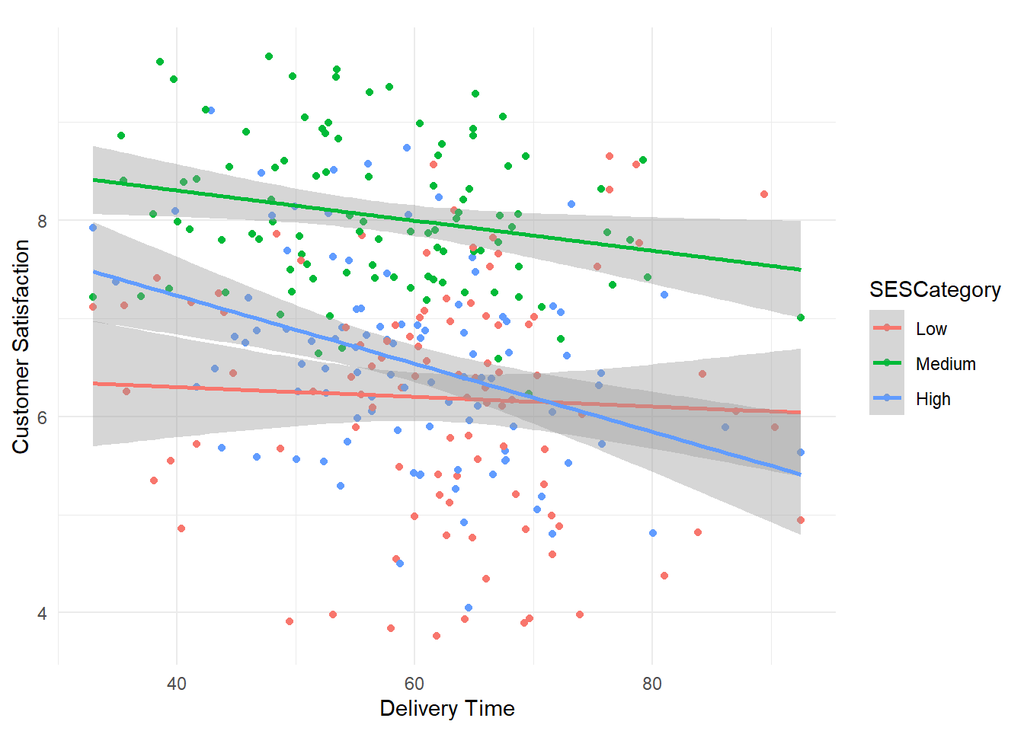

```r
# Plotting the Scatter plot for DeliveryTime and CustSatisfaction based on different SESCategory
ggplot(cust.satisfaction, aes(x = DeliveryTime, y = CustSatisfaction, color = SESCategory)) +
  labs(x="Delivery Time", y="Customer Satisfaction", title=expression()) +
  geom_point() +
  geom_smooth(method = "lm") +
  theme_minimal()
```

## Conclusion

The analysis shows that customer satisfaction is influenced by several factors, including the socio-economic status (SES) of the store’s location. Stores in medium SES areas tend to have higher customer satisfaction scores compared to low SES stores, and high SES stores also have slightly higher satisfaction scores, though the difference is smaller. Delivery time only affects satisfaction in high SES stores—longer delivery times lead to lower satisfaction. Staff satisfaction plays an important role, with higher staff satisfaction linked to higher customer satisfaction. However, offering a new range of products does not significantly impact satisfaction. By adding an interaction term between delivery time and SES, the model’s accuracy improved slightly, indicating that delivery time affects satisfaction differently depending on the SES of the store’s location. Overall, focusing on faster delivery and improving staff satisfaction, especially in high SES areas, would be effective ways to boost customer satisfaction.